# Activad3_Toy

# Objetivo

Construye un clasificador naïve Bayes para clasificar la observación $\tilde{x}=(0.4,1.5,\text{Level1})$

```r
library(tidyverse)
```

## Cargar datos

```r
data = read.csv("../data/toy_bayes.csv", stringsAsFactors = TRUE)
head(data)
```

| x1 | x2 | x3 | y |
| --- | --- | --- | --- |
| -1.083323 | 2.725833 | Level3 | Class0 |
| -1.683077 | -1.176222 | Level2 | Class1 |
| -2.003365 | 3.826674 | Level1 | Class1 |
| 1.227836 | 1.856215 | Level3 | Class0 |
| -1.563035 | -1.047976 | Level1 | Class1 |
| -1.970818 | -4.671922 | Level1 | Class1 |

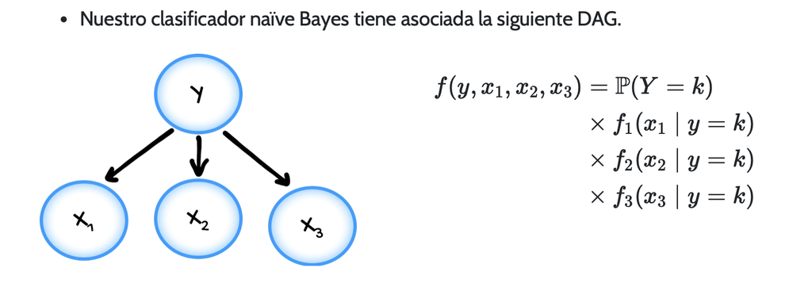

# Hacer la observación nueva

```r
x_tilde = tibble(y = c("Class0", "Class1"),
                 x1 = rep(0.4, 2), x2 = rep(1.5, 2))
```

# Prior

$$\mathbb{P}(Y = k)$$

- Iniciaremos la estimación de nuestra red bayesiana con el nodo padre, es decir, la distribución prior de la variable de clase $y$.
- Para esto simplemente contamos el número de observaciones en cada clase y dividimos entre el total.

```r
prior = data |>
            group_by(y) |>  ## Agrupamos por la etiqueta
            summarise(n = n()) |> ## Contamos el número de observaciones de cada clase
            mutate(prior_prob = n/sum(n)) ## Calculamos las probabilidades a priori
prior
```

| y | n | prior_prob |
| --- | --- | --- |
| Class0 | 209 | 0.418 |
| Class1 | 291 | 0.582 |

- funcion n() solo cuenta (como COUNT en excel)
- mutate crea nuevas variables o modifica alguna que ya existe

# Visualizaciones

## Función de densidad para x1 y Class0

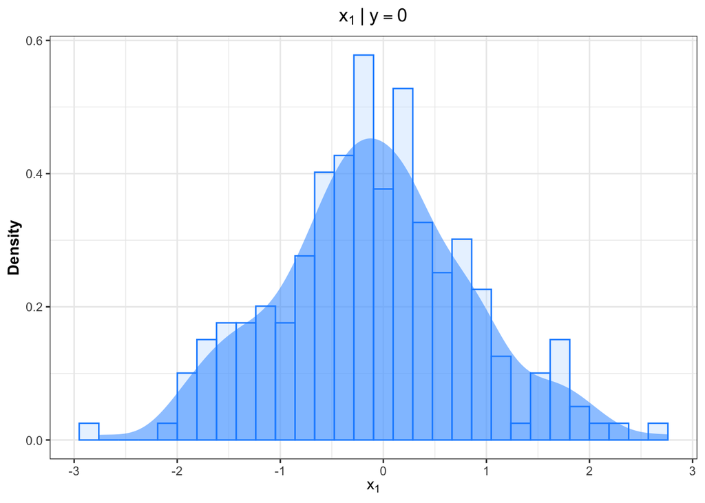

```r
data |>
    filter(y == "Class0") |>
    ggplot(aes(x = x1, y = after_stat(density))) +
    geom_histogram(color = "dodgerblue", fill = "slategray1", alpha = 0.4) +
    geom_density(fill = "dodgerblue", color = NA, lwd = 1, alpha = 0.5) +
    labs(x = expression(x[1]), y = "Density", title = expression(x[1] ~ "|" ~ y == 0)) +
    theme_bw() +
    theme(plot.title = element_text(hjust = 0.5, face = "bold",
                                    margin = margin(0, 0, 5, 0)),
            axis.title.x = element_text(face = "bold"),
            axis.title.y = element_text(face = "bold", angle = 90),
            legend.title = element_text(hjust = 0.5, face = "bold"),
            legend.text = element_text(hjust = 0.5),
            strip.text = element_text(size = 14, hjust = 0.5, face = "bold",
                                      margin = margin(2, 3, 3, 3)))
```

## Bar de $x_3$ en clase 0

- Realizamos un bar chart para visualizar la distribución de $x_3$ en la clase 0.

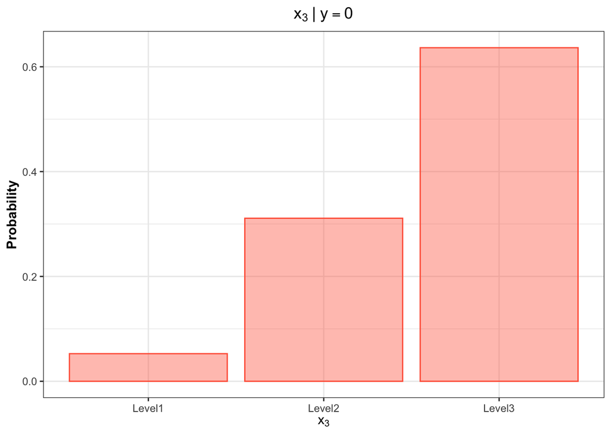

```r
data |>
    filter(y == "Class0") |>
    ggplot(aes(x = x3, y = after_stat(count/sum(count)))) +
    geom_bar(color = "tomato1", fill = "tomato1", alpha = 0.4) +
    labs(x = expression(x[3]), y = "Probability", title = expression(x[3] ~ "|" ~ y == 0)) +
    theme_bw() +
    theme(plot.title = element_text(hjust = 0.5, face = "bold",
                                    margin = margin(0, 0, 5, 0)),
            axis.title.x = element_text(face = "bold"),
            axis.title.y = element_text(face = "bold", angle = 90),
            legend.title = element_text(hjust = 0.5, face = "bold"),
            legend.text = element_text(hjust = 0.5),
            strip.text = element_text(size = 14, hjust = 0.5, face = "bold",
                                      margin = margin(2, 3, 3, 3)))
```

|> significa pipe, $y$ es la densidad,

(y= 0 ) es la categoría

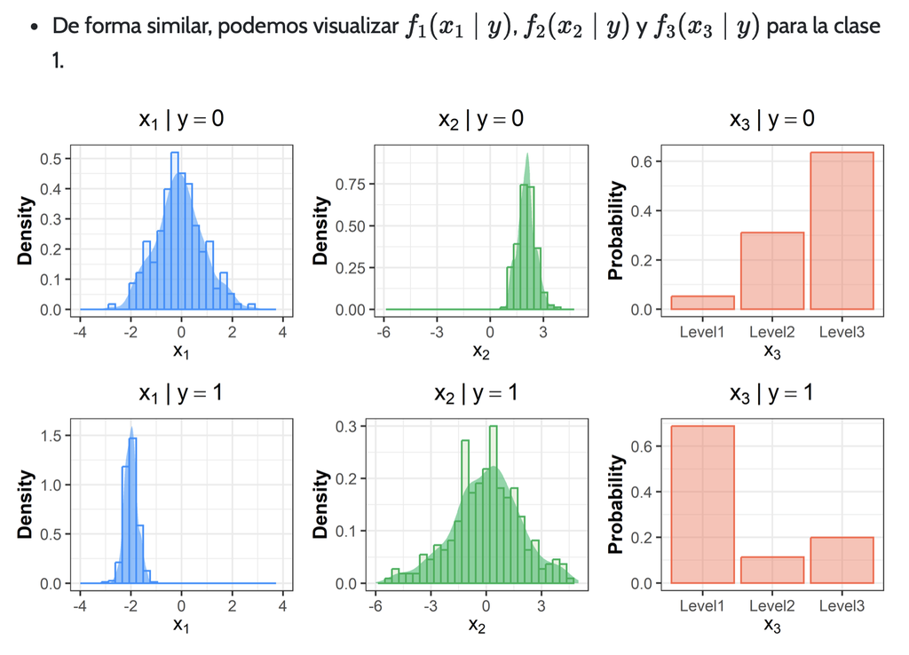

# Estimar densidad de $f(x_1 \mid y) \text{ y } f(x_2 \mid y)$

- lo haremos de forma no paramétrica
  - tipo kernel
  - (la curva fea de atrás del gráfico)

$n$ = num observaciones

$h$ = factor the bandwidth, hiperparámetro de suavizamiento

por la suma de todas las observaciones de la función K() <– kernel function

$$\hat{f}_1(x_1 \mid y) =
\frac{1}{n h} \sum_{i=1}^{n} K\!\left(\frac{x_1 - x_i}{h}\right)$$

- todas las formas de estimar el kernel SON CON ESTA FÓRMULA

# Calcular Bandwiths

vamos a extraer bandwiths

- La estimación de las densidades se realiza mediante la función `density()`.
- Podemos acceder a los bandwidths mediante el operador `$`.
- Para cada clase, obtenemos los bandwidths de $x_1$ y $x_2$.

```r
bws = data |>
        group_by(y) |>                            ## Agrupamos por la etiqueta
        summarise(bw1 = density(x1)$bw,  ## Extraemos los bandwidths
                   bw2 = density(x2)$bw)
bws
```

| y | bw1 | bw2 |
| --- | --- | --- |
| Class0 | 0.2596874 | 0.1299572 |
| Class1 | 0.0706991 | 0.4982160 |

extraemos bw para cada clase para cada x_i

tienen que tener repetir cada observacion por clase (si hubieran 3 se hace tres veces)

–

# Función k

- Implementamos una función que calcule el kernel gaussiano.

```r
K = function(x){
    return(exp(-x^2/2)/ sqrt(2*pi))
}
```

- usar estimador tipo kernel
- implementamos una función para calcular la densidad estimada usando ese kernel.

```r
kernel = function(x, data, bw){
    return(mean(K((x-data)/bw))/bw)
}
```

- Con esto tendríamos totalmente estimadas $f(x_1 \mid y) \text{ y } f(x_2 \mid y)$
- Para estimar $f(x_3 \mid y)$ basta con contar el número de observaciones en cada nivel de esta variable en cada clase y dividirlo entre el total.

## Ejemplo con x_3

ver número de veces que sale cada categoría de $x_3$ y la probabilidad de que salga cada una

- Por ejemplo, para la primera clase estimamos la probabilidad de cada uno de los niveles de $x_3$

```r
data |>
    filter(y == "Class0") |>
    group_by(x3) |>
    summarise(n = n()) |>
    mutate(prob = n/sum(n))
```

| x3 | n | prob |
| --- | --- | --- |
| Level1 | 11 | 0.0526316 |
| Level2 | 65 | 0.3110048 |
| Level3 | 133 | 0.6363636 |

group es solo decirle que está agrupado

sumarize le dice que empieze a hacer conteos

n = numero de observaciones

prob de cada Level

# Calcular nueva Observación

Para realizar la clasificación de la nueva observación usando nuestro **clasificador naïve Bayes** usaremos la **regla de Bayes**:

$$\mathbb{P}(Y = k \mid \mathbf{X} = \tilde{\mathbf{x}}) =
\frac{\mathbb{P}(Y = k) \displaystyle\prod_{j=1}^{3} \hat{f}^{j}(\tilde{x}_{j} \mid y = k)}
{\displaystyle \sum_{\ell = 0}^{1} \mathbb{P}(Y = \ell) \prod_{j=1}^{3} \hat{f}^{j}(\tilde{x}_{j} \mid y = \ell)}$$

Necesitamos evaluar $\hat{f}^{1}(x_{1} \mid y) \quad \text{y} \quad \hat{f}^{2}(x_{2} \mid y)$ en $\tilde{x}_{1} \quad \text{y} \quad \tilde{x}_{2}$ respectivamente.

## Armar Tabla con observación nueva

- Creamos una tabla uniendo las nuevas observaciones con la tabla donde encontramos los bandwidths de $x_1$ y $x_2$ para cada clase usando la función `left_join()`.

```r
num_probs = x_tilde |>
                left_join(bws, by = "y")
num_probs
```

| y | x1 | x2 | bw1 | bw2 |
| --- | --- | --- | --- | --- |
| Class0 | 0.4 | 1.5 | 0.2596874 | 0.1299572 |
| Class1 | 0.4 | 1.5 | 0.0706991 | 0.4982160 |

# Density Kernel Evaluado

```r
num_probs = num_probs |>
                group_by(y) |>                            ## Agrupamos por la etiqueta
                summarise(kernel1 = kernel(x1, data$x1,bw1),   ## Calculamos los kernels
                           kernel2 = kernel(x2, data$x2, bw2)) |>
                select(y, kernel1, kernel2) ## Seleccionamos sólo la etiqueta y los kernels
num_probs
```

| y | kernel1 | kernel2 |
| --- | --- | --- |
| Class0 | 0.1480754 | 0.2483374 |
| Class1 | 0.1355984 | 0.2708991 |

calculamos $f_3(\tilde{x}_3 \mid y)$ (parted de arriba de bayes), en x3 agarra solo el valor de Level 1

- Para obtener $f_3(\tilde{x}_3 \mid y)= \mathbb{P}(X_3=Level1 \mid y)$ , simplemente contamos el número de observaciones donde $x_3= \text{Level1}$ para cada clase, y dividimos entre el total de observaciones en cada clase.

```r
cat_probs = data |>
                group_by(y, x3) |> ## da 6 combinaciones   ## Realizamos la agrupación por la etiqueta y x3
                summarise(n = n()) |>    ## Contamos el número de observaciones, estas son las combinaciones, se divide entre cada clase de y
                group_by(y) |>        ## Agrupamos por la etiqueta
                mutate(prob = n/sum(n)) |> ## Calculamos las probabilidades
                filter(x3 == "Level1")           ## Seleccionamos sólo el caso cuando x3 = Level1
```

[output not shown]

```r
cat_probs
```

| y | x3 | n | prob |
| --- | --- | --- | --- |
| Class0 | Level1 | 11 | 0.0526316 |
| Class1 | Level1 | 200 | 0.6872852 |

- Calculamos el denominador de la regla de Bayes sumando $\mathbb{P}(Y=k)f_1(\tilde{x}_1 \mid y)f_2(\tilde{x}_2 \mid y)f_3(\tilde{x}_3 \mid y)$ para cada clase.

```r
total = sum(prior$prior_prob * num_probs$kernel1 * num_probs$kernel2 * cat_probs$prob)
```

- Finalmente, obtenemos las probabilidades a posteriori para cada clase.

```r
(prior$prior_prob * num_probs$kernel1 * num_probs$kernel2 * cat_probs$prob)/total
```

```
[1] 0.05218539 0.94781461
```

resultado es [class 0, Class 1]

- Asignaríamos la nueva observación a la segunda clase (`Class1`).